# Cumulative Annual Emission Estimation Protocol

Caitie Ciampaglia

2025-08-29

#### Objective

The objective of this protocol is to outline the steps necessary to **estimate cumulative annual greenhouse gas emissions**. This protocol uses **linear interpolation** to upscale daily flux measurements to cumulative annual emission estimates.

#### Set Up

**1.** Start by installing necessary packages and functions into your library.

**Click to expand**

```r
#install.packages("here")
library(here)
#install.packages("data.table")
library(data.table)
#install.packages("lubridate")
library(lubridate)
```

```r
library(tibble)
#install.packages("ggplot2")
library(tidyverse)
library(ggpubr)
#install.packages("Rmisc")
library(Rmisc)
#install.packages("plotrix")
library(plotrix)
#install.packages("formattable")
library(formattable)
#install.packages("ggthemes")
library(ggthemes)
#install.packages()
library(dplyr)
#to export an R Markdown file into a PDF
library(rmarkdown)
library(tinytex)
#install.packages("tinytex")
#tinytex::install_tinytex()
```

**2.** Before beginning or importing any data, make sure your file structures are set up effectively. Do this by creating one main project folder (i.e., Cumulative Emission R Code) and a set of subfolders. Use the following subfolder structure to stay organized:

- *Analysis* — Where your R Markdown file will be stored once knit.
- *Fluxes* — Where raw, unprocessed flux files are stored.
- *Data* — Where other data, like treatment lists are stored.
- *Output* — Where outputs are generated, like plots and figures.

*Note:* If you use this file structure the working directory should be based in the main project folder, which allows you to reference the files inside the subfolders.

**3.** When working in an R Studio file, set the working directory and import calculated flux data. Import the flux data by setting the pathway to the ‘Fluxes’ subfolder.

```r
setwd("/Users/caitieciampaglia/Cumulative Emission R Code")
flux_paths <- list.files(paste(getwd(),'/Fluxes',sep = ''), pattern='.rda', full.names=TRUE)
```

**4.** Combine calculated daily flux results into one `date.frame`.

```r
flux <- data.frame(readRDS(flux_paths[1]))
for (i in 2:length(flux_paths)) {

  data <- readRDS(flux_paths[i])
  flux <- rbind(flux, data)
}
```

**5A.** Load the list of treatments applied in the experiment into the `data.frame`, and specifically select the treatment and plot columns.

```r
treatmentlist <- read.csv(paste(getwd(),"/Data/Treatment to Plot - Hazelnut Chilli.csv",sep = '')) %>%
  select(Plot, Treatment1) #%>%
 # rename("Treatment1"="Treatment")
```

**5B.** Remove the treatment assignments as they may not be accurate to your data set. Instead, we will load in an updated `.csv` file with the correct treatment assignments in the next step. But first, modify the `flux data.frame` and rename it as `flux1`.

```r
flux1 <- flux %>%
  select(-Treatment1)
```

**5C.** Fix up the `data.frames` by adding another treatment column — this will ensure data tables have the same number of columns and are compatible. Next, join the original `treatmentlist` with the `flux1` `data.frame`, resulting in the object `flux`. This will be used going forward.

```r
flux1["Treatment2"] <- NA
flux1 <- full_join(treatmentlist, flux1, multiple="all") %>%
  relocate(start, Treatment1, Treatment2, Plot)
flux <- flux1
```

**6.** Convert the `data.frame` into a `data.table`, which is best for large data sets.

```r
flux <- as.data.table(flux)
```

**7.** Subsetting can also be done for different scenarios or specific dates.

```r
f_2018 <- flux[Date>="2018-04-26",]
```

#### Quality Assurance

**Quality assurance (QA)** is a critical step in the flux fitting process and must be completed before interpolating cumulative annual emission estimates. Each flux is evaluated individually and assigned to a category. Although no flux data should be discarded from the dataset, categorizing fluxes improves the efficiency of data processing by separating unreliable fluxes earlier on.

Flux reliability can be assessed using **Relative Root Mean Squared Error (rRMSE)**. Low rRMSE values indicate a good model fit with predictions close to observed values; an rRMSE of 0 represents a perfect fit. rRMSE thresholds of **0.01 for carbon dioxide** and **0.05 for nitrous oxide and methane** are applied. Carbon dioxide has a lower rRMSE value as it is more likely to follow a linear relationship when compared to nitrous oxide and methane. The proportion of fluxes below each threshold can be summarized in a table and visualized in a column graph. Ideally, fluxes will fall below the rRMSE thresholds, but if they fall above the rRMSE thresholds, they will be categorized as unreliable.

After removing unreliable fluxes, the dataset can be reviewed more closely to evaluate borderline cases. The second stage of **QA** further categorizes fluxes using the following decision-making tree (Fig. 1) to assign each flux to one of four categories: *Reliable*, *Insignificant*, *Zeroed Value*, and *Not Recommended*.

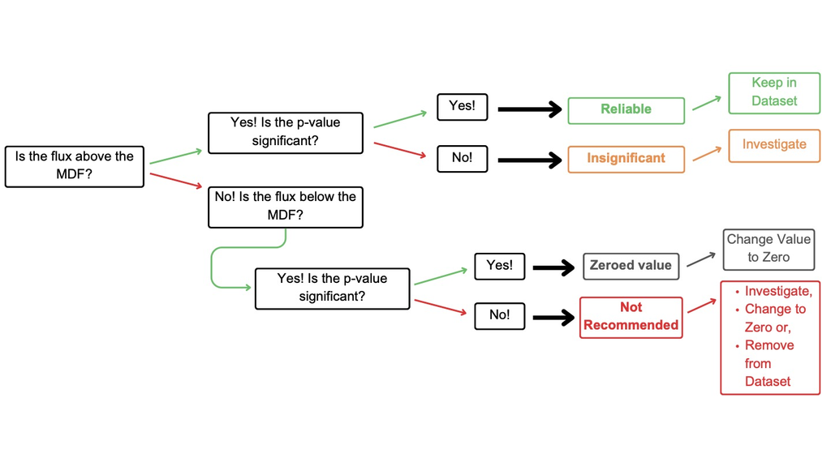

**Figure. 1** Decision-making tree used for flux quality assurance.

**1.** A function can be built to carry out both stages of **Quality Assurance**. The function is named `qa_fun`, referring to the *Quality Assurance Function*. Inside of the function, the placeholder `dt` represents the input dataset. Because `dt` acts as a placeholder it ensures our function is reusable and compatible with other datasets we may want to use in the future. Within the function, a table and a plot can also be created to visualize the information. Because the code within the function must all be run together inside of the { } brackets, the explanations and specific steps have been added inside the code chunk below as comments.

```r
qa_fun <- function(dt) {

#1A. This section of code conducts the first stage of QA by counting the proportion of fluxes in the dataset that are above the rRMSE thresholds.  This number is then divided by the number of rows in the dataset, resulting in a percentage.  This is completed for each greenhouse gas (nitrous oxide, methane, and carbon dioxide).
n2o_rRMSE <- percent(nrow(dt[rRMSE_n2o > 0.05,])/nrow(dt),digits = 0)
ch4_rRMSE <- percent(nrow(dt[rRMSE_ch4 > 0.05,])/nrow(dt),digits = 0)
co2_rRMSE <- percent(nrow(dt[rRMSE_co2 > 0.01,])/nrow(dt),digits = 0)

#1B. This section of code conducts the second stage of QA by counting the proportion of fluxes in the dataset that fall into each category: 'Good', 'Bad', 'Insignificant', and 'Zero'.  Again, this is done for each greenhouse gas (nitrous oxide, methane, and carbon dioxide).
n2o_good <- percent(nrow(dt[QA_n2o == 'Good',])/nrow(dt),digits = 0)
n2o_bad <- percent(nrow(dt[QA_n2o == 'Bad',])/nrow(dt),digits = 0)
n2o_insig <- percent(nrow(dt[QA_n2o == 'Insignificant',])/nrow(dt),digits = 0)
n2o_zero <- percent(nrow(dt[QA_n2o == 'Zero',])/nrow(dt),digits = 0)

ch4_good <- percent(nrow(dt[QA_ch4 == 'Good',])/nrow(dt),digits = 0)
ch4_bad <- percent(nrow(dt[QA_ch4 == 'Bad',])/nrow(dt),digits = 0)
ch4_insig <- percent(nrow(dt[QA_ch4 == 'Insignificant',])/nrow(dt),digits = 0)
ch4_zero <- percent(nrow(dt[QA_ch4 == 'Zero',])/nrow(dt),digits = 0)

#1C. This section of code creates vectors to organize the results: `gastype` indicates which greenhouse gas each row refers to, `fluxcat` indicates the QA category (Good/Bad/Insignificant/Zero), and `pcnt` indicates the calculated percentage for each category.
gastype <- c('N2O','N2O','N2O','N2O','CH4','CH4','CH4','CH4')
fluxcat <- c('Good','Bad','Insignificant','Zero','Good','Bad','Insignificant','Zero')
pcnt <- c(n2o_good,n2o_bad,n2o_insig,n2o_zero,ch4_good,ch4_bad,ch4_insig,ch4_zero)

#1D. Lastly, all vectors are combined into a `data.frame`, which creates a table summarizing all of the QA information just determined.
df <- data.frame(gastype,fluxcat,pcnt)

#1E. Using the `data.frame` just made we can create a stacked horizontal bar chart to help visualize our data.  The bar chart will represent the percentage of fluxes (`pcnt`) by category (`fluxcat`), separately for each greenhouse gas (`gastype`).
  p <- ggplot(df, aes(x=gastype,y=pcnt))
  p+geom_bar(stat="identity", width = 0.5, position="stack", aes(fill=fluxcat)) +
    geom_text(aes(label = paste0(pcnt), y = c(0.75,1.02,0.4,0.15,
                                              0.9,1.02,0.75,0.4)),
               size = 5, color = "black")+
    coord_flip() +
    scale_fill_brewer(palette="Spectral") +
    theme_minimal() +
    theme(legend.position="bottom",
          legend.title = element_blank())+
    labs(x="",y='')+
    scale_fill_discrete(labels=c("Not Recommended", "Reliable", "Insignificant", "Zeroed Value"))

}
```

**2.** Display the stacked horizontal bar chart to visualize the data.

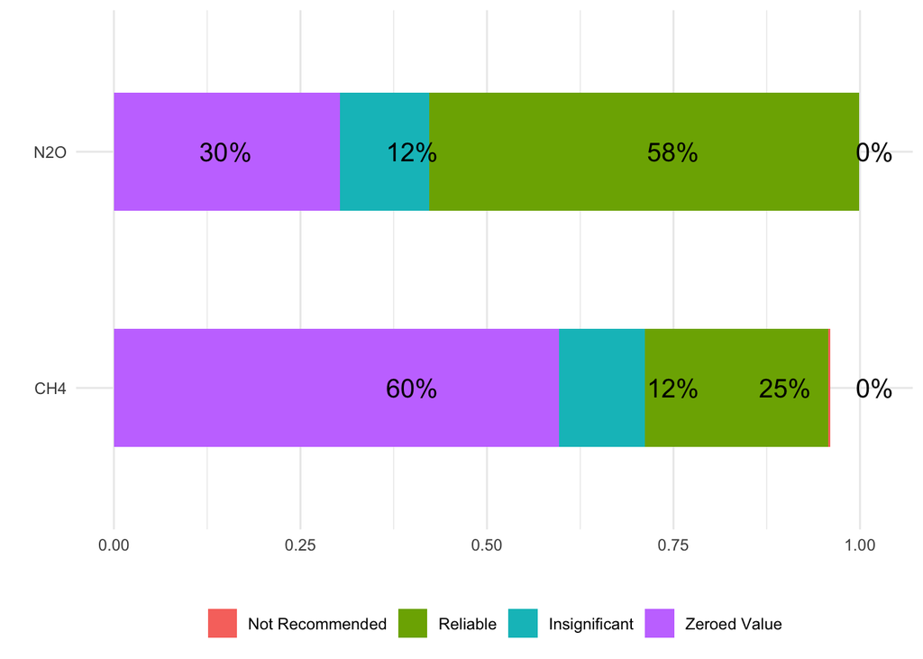

```r
qa_fun(flux)
```

**Figure. 2** Stacked horizontal bar chart representing the percentage of nitrous oxide and methane fluxes that fall into each category: ‘Not Recommended’, ‘Reliable’, ‘Insignificant’, and ‘Zeroed Value’.

```r
plot_MDF_fun <- function(dt){

#3A. Pull up the summary statistics to calculate the mean, standard error, and sample size for the dataset.  This can also be used to aggregate the flux data by date and treatment.
  summary = function(x) list(mean = mean(x), stderr = std.error(x), N = length(x))

#3B. Convert the raw flux rate units into units that are more interpretable for plotting.
  mmol_conv <- 3.6 # 1 umol/m^2/s *(3600s/1hr)*(1 mmol/1000 umol) = 3.6 mmol/m^2/hr
  umol_conv <- 3600 # 1 umol/m^2/s *(3600s/1hr) = 3600 umol/m^2/hr

#3C. Aggregate fluxes by date and treatment for each greenhouse gas.
  QA_co2 <- dt[, unlist(lapply(.SD, summary), recursive = FALSE),
               .SDcols = c('F_co2','MDL_co2'), by = c('Date','Treatment1')][
                 ,F_co2_mmol := F_co2.mean*mmol_conv][
                   ,stderr_mmol := F_co2.stderr*mmol_conv][
                     ,MDL_co2_mmol := MDL_co2.mean*mmol_conv]
  QA_n2o <- dt[, unlist(lapply(.SD, summary), recursive = FALSE),
               .SDcols = c('F_n2o','MDL_n2o'), by = c('Date','Treatment1')][
                 ,F_n2o_umol := F_n2o.mean*umol_conv][
                   ,stderr_umol := F_n2o.stderr*umol_conv][
                     ,MDL_n2o_umol := MDL_n2o.mean*umol_conv]
  QA_ch4 <- dt[, unlist(lapply(.SD, summary), recursive = FALSE),
               .SDcols = c('F_ch4','MDL_ch4'), by = c('Date','Treatment1')][
                 ,F_ch4_umol := F_ch4.mean*umol_conv][
                   ,stderr_umol := F_ch4.stderr*umol_conv][
                     ,MDL_ch4_umol := MDL_ch4.mean*umol_conv]

#3D. Often, NA values may be produced in flux datasets, stemming from issues during measurement, undetectable flux values (this is especially true for methane), or issues in data processing.  For this reason, our plotting functions may run more effectively if we convert any NA values into zeros.  This provides us with a short-term solution, but understanding the source of these NA values is important to producing a reliable and concise code in the long-term.

QA_co2[is.na(QA_co2)] <- 0
QA_n2o[is.na(QA_n2o)] <- 0
QA_ch4[is.na(QA_ch4)] <- 0

dt[is.na(dt)] <- 0

#3E. This section of code creates several graphs that plot flux data for each greenhouse gas against the MDF, which is shown in red.  This visually indicates which fluxes are below the detection limit.
  p3 <- ggplot(QA_n2o,aes(Date,F_n2o_umol))
  print(p3 + geom_point(aes(shape=Treatment1),size = 2)+
    stat_smooth(aes(Date,F_n2o_umol), se = TRUE, linewidth = 1)+
    geom_line(aes(y=MDL_n2o_umol),linewidth = 1, linetype = 2, colour='red')+
    scale_x_date(date_breaks = "1 month")+
    labs (y = expression(N[2]*O~Flux~(umol~N[2]*O~m^-2~hr^-1)))+
    theme_bw()+
    theme(panel.grid.major = element_blank(),
          panel.grid.minor = element_blank(),
          plot.margin = unit(c(0.5,0.5,0.5,0), "lines"),
          axis.title.y = element_text(size= 12,face="bold"),
          axis.title.x = element_blank(),
          axis.text.x = element_text(angle=60, hjust=1,face="bold"),
          axis.ticks.x = element_blank())
  )
dt <- dt %>%
  mutate(F_n2o=F_n2o*1000)

  p4 <- ggplot(dt,aes(Date,F_n2o,colour=Treatment1))
  print(p4 + geom_point(size = 1)+
    stat_smooth(aes(Date,F_n2o), se = TRUE,linewidth = 1)+
    geom_point(aes(y=MDL_n2o),size = 1, colour='red')+
    scale_x_date(date_breaks = "1 month")+
    labs (y = expression(N[2]*O~Flux~(umol~N[2]*O~m^-2~hr^-1)))+
    theme_bw()+
    theme(panel.grid.major = element_blank(),
          panel.grid.minor = element_blank(),
          plot.margin = unit(c(0.5,0.5,0.5,0), "lines"),
          axis.title.y = element_text(size= 12,face="bold"),
          axis.title.x = element_blank(),
          axis.text.x = element_text(angle=60, hjust=1,face="bold"),
          axis.ticks.x = element_blank()))

  p5 <- ggplot(QA_ch4,aes(Date,F_ch4_umol))
  print(p5 + geom_line(linewidth = 1)+
    geom_ribbon(aes(ymin = F_ch4.mean-F_ch4.stderr, ymax = F_ch4.mean+F_ch4.stderr),
                fill = "grey70",alpha = 0.3)+
    geom_line(aes(y=-MDL_ch4.mean),linewidth = 1,linetype = 3, colour='red')+
    #scale_y_continuous(breaks=c(1,2,3,4,5))+
    scale_x_date(date_breaks = "1 month")+
    labs (y = expression(CH[4]~Flux~(umol~m^2~CH[4]~s^-1)))+
    theme_bw()+
    theme(panel.grid.major = element_blank(),
          panel.grid.minor = element_blank(),
          plot.margin = unit(c(0.5,0.5,0.5,0), "lines"),
          axis.title.y = element_text(size= 12,face="bold"),
          axis.title.x = element_blank(),
          axis.text.x = element_text(angle=60, hjust=1,face="bold"),
          axis.ticks.x = element_blank()))

#The following sections are commented out because there is no carbon dioxide flux mean being generated in the previous code.  Likely, a prior version of this code generated these means, but it has since been removed.  For this reason, the ribbon will not be generated for this plot.  In order to fix it, this code needs to be added back in somewhere above.
  p6 <- ggplot(dt,aes(Date,F_co2*mmol_conv))
  print(p6 + geom_point(size = 1)+
    stat_smooth(aes(Date,F_co2*mmol_conv), method = "gam", se = TRUE, formula = y ~ s(x, bs = "cs"), linewidth = 1)+
    #geom_smooth(method = "gam", se = TRUE,
                #data =QA_co2,
                #aes(Date,F_co2.mean),
               # alpha=0.3,  size=0.5, color = "#00798c")+
    #geom_ribbon(aes(ymin = F_co2.mean-F_co2.stderr, ymax = F_co2.mean+F_co2.stderr),
                #fill = "grey70",alpha = 0.3)+
    geom_point(aes(y=MDL_co2*mmol_conv),size = 1, colour='red')+
    #scale_y_continuous(breaks=c(1,2,3,4,5))+
    scale_x_date(date_breaks = "1 month")+
    labs (y = expression(CO[2]~Flux~(mmol~CO[2]~m^-2~hr^-1)))+
    theme_bw()+
    theme(panel.grid.major = element_blank(),
          panel.grid.minor = element_blank(),
          plot.margin = unit(c(0.5,0.5,0.5,0), "lines"),
          axis.title.y = element_text(size= 12,face="bold"),
          axis.title.x = element_blank(),
          axis.text.x = element_text(angle=60, hjust=1,face="bold"),
          axis.ticks.x = element_blank()))

  p7 <- ggplot(QA_co2,aes(Date,F_co2_mmol))
  print(p7 + geom_point(aes(shape=Treatment1),size = 2)+
    stat_smooth(aes(Date,F_co2_mmol),method = 'gam',
                formula = y ~ s(x, bs = "cs"), se = TRUE, linewidth = 1)+
    geom_line(aes(y=MDL_co2_mmol),linewidth = 1, linetype = 2, colour='red')+
    scale_x_date(date_breaks = "1 month")+
    labs (y = expression(CO[2]~Flux~(mmol~CO[2]~m^-2~hr^-1)))+
    theme_bw()+
    theme(panel.grid.major = element_blank(),
          panel.grid.minor = element_blank(),
          plot.margin = unit(c(0.5,0.5,0.5,0), "lines"),
          axis.title.y = element_text(size= 12,face="bold"),
          axis.title.x = element_blank(),
          axis.text.x = element_text(angle=60, hjust=1,face="bold"),
          axis.ticks.x = element_blank()))
}
```

**4.** Display the plots.

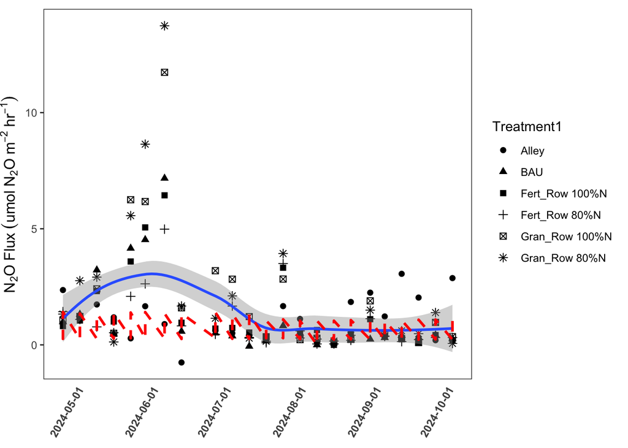

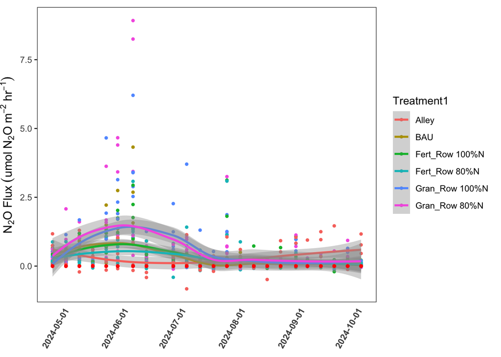

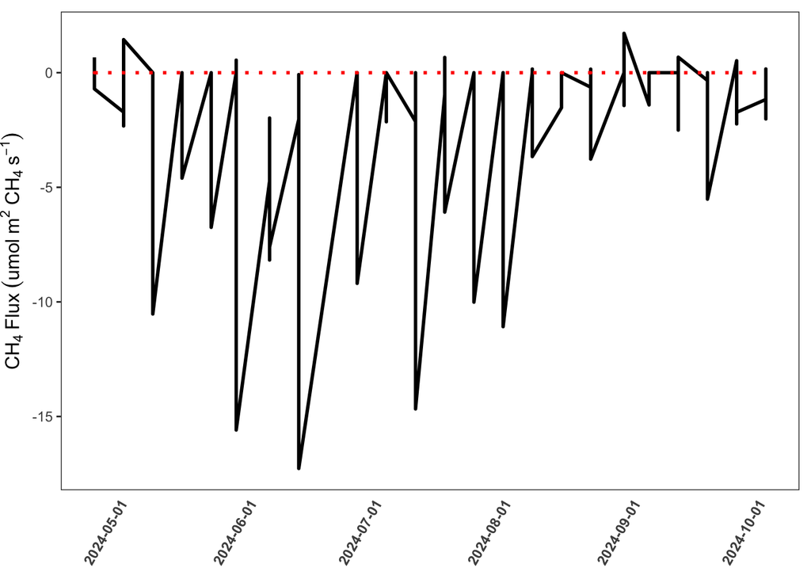

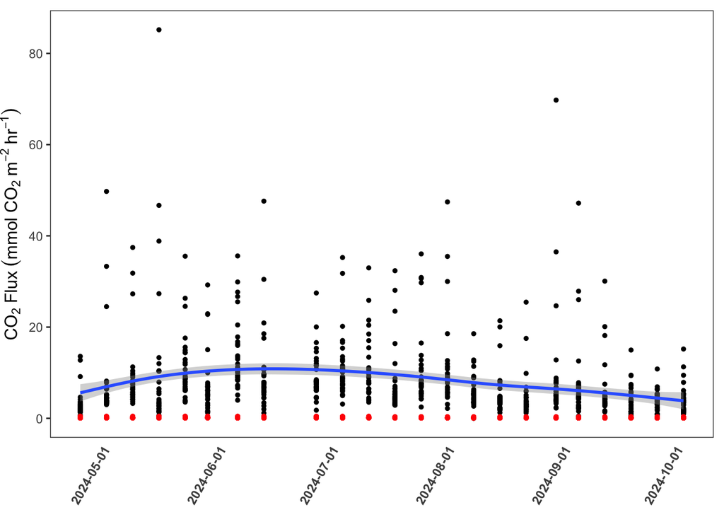

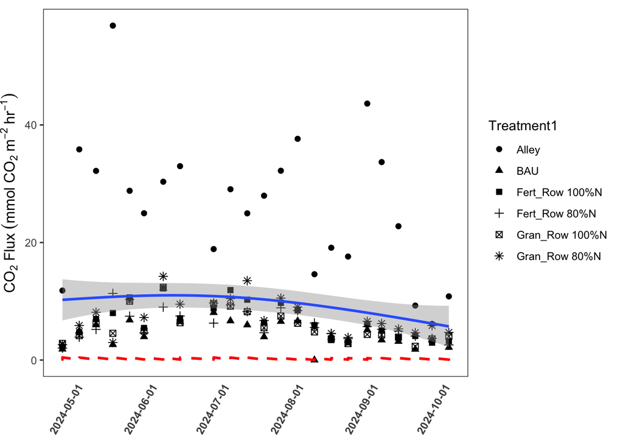

```r
plot_MDF_fun(flux)
```

#### Flux Interpolation and Cumulative Emission Estimation

Following data preparation and **Quality Assurance**, we are now ready to **interpolate daily fluxes**. Interpolation aims to fill gaps in the data that occur between *in situ* greenhouse gas measurements, allowing for the computation of cumulative emission estimates. By estimating cumulative emissions, we can gain an understanding of plot-level emissions over time.

**1.** Define where the output files will be saved (`outpath`), as well as the name for the final combined emission file (`outname`).

```r
outpath <- "/Users/caitieciampaglia/Cumulative Emission R Code/Output"
outname <- 'Cumulative GHGs emission_2023May-2023May_UBCF'
```

**2.** Create the main data processing function. It will complete the following:

- **Average flux data** for each plot and day
- **Fill in data gaps** between measurements using linear interpolation
- Calculate **cumulative emission estimates**
- **Export** results

*Note:* Like any function, it must be run as a continuous code chunk; follow the internal comments for specific steps.

```r
flux_interpolation <- function(dt){

#2A. In case some plots were measured more than once a day, take an average so there is only one value per plot per date.
  f_co2 <- dt[, lapply(.SD, mean),.SDcols = 'kg.ha.day_co2c',
              by=.(Date,Treatment1,Treatment2,Plot)]
  f_n2o <- dt[, lapply(.SD, mean),.SDcols = 'g.ha.day_n2on',
              by=.(Date,Treatment1,Treatment2,Plot)]
  f_ch4 <- dt[, lapply(.SD, mean),.SDcols = 'g.ha.day_ch4c',
              by=.(Date,Treatment1,Treatment2,Plot)]

#2B. Combine all three greenhouse gases into one unified dataset.  The dataset will be stored in the global environment so it can also be used outside the function if needed.
  f_ghgs <- cbind(f_co2,f_n2o$g.ha.day_n2on,f_ch4$g.ha.day_ch4c)
  f_ghgs <- setNames(f_ghgs, c("Date","Treatment_1", "Treatment_2","Plot","kg.ha.day_co2c", "g.ha.day_n2on", "g.ha.day_ch4c"))
  .GlobalEnv$f_ghgs <- f_ghgs

#2C. In this step, linear interpolation is used to fill in data gaps.  It does so using a 'loop', which allows for the same interpolation and cumulative emission calculations to be made for each plot automatically, which helps save additional steps that would otherwise be done manually.

  x <- c(1:18) # If you have one chamber per plot, set this to the number of plots you have.
  options(warn=2)
  for (val in x) {
    dt.split <- split(f_ghgs,f = f_ghgs$Plot) # Splits data by Plot ID.
    dt <- dt.split[[val]] # Chooses the rows for plot 'val' (a value in 1:36).
    dt <- as.data.table(dt)

#2D. Determine gaps between measurement dates by finding the time difference between consecutive measurements.
    date<-unique(dt[,.(Date)])
    Date.end <-date$Date[2:nrow(dt)]
    Date.end[nrow(dt)]<-NA
    Date.end<-as.data.table(Date.end)
    date<-cbind(date,Date.end)

    # Obtain the number of days in between each measurement.
    date$daynum<-as.Date(as.character(date$Date.end), format="%Y-%m-%d")-as.Date(as.character(date$Date), format="%Y-%m-%d")
    date[is.na(daynum),':='(daynum=1)] # Sets the last NA to equal 1.
    dt<-date[dt,on=.(Date)] # Add date to dt by matching via Date
    dt[is.na(Date.end),':='(Date.end=Date)]

#2E. Expand data table to fill in missing dates.  In this case, the number of rows is equal to the total days multiplied by the number of chambers.

# Make room to fill estimated daily emissions.  `Datenew` is the interpolated daily date.
    dtnew<-dt[,.(n=rep(1:daynum)),by=.(Date,Treatment_1,Treatment_2,Plot,kg.ha.day_co2c, g.ha.day_n2on, g.ha.day_ch4c,Date.end,daynum)]
    dtnew[,':='(Datenew=Date+n-1)] # Fill up date gaps between measurements.
    dtnew<-dtnew[order(Plot,Date)]

#2F. Merge end value back to dt.
    dt.end<-unique(dt[,.(Date,Plot,Treatment_1,Treatment_2,kg.ha.day_co2c, g.ha.day_n2on, g.ha.day_ch4c)])
    setnames(dt.end,c("Date", "kg.ha.day_co2c","g.ha.day_n2on", "g.ha.day_ch4c"),
             c("Date.end","kg.ha.day_co2c.end","g.ha.day_n2on.end","g.ha.day_ch4c.end"),skip_absent=TRUE)

    dtnew<-dt.end[dtnew,on=.(Date.end,Plot)]

#2G. Calculate estimated daily emission using linear fit (i.e. interpolation) between 2 neighbouring measurements.
    dtnew[,':='(est.kg.ha.day_co2c=(n-1)*(kg.ha.day_co2c.end-kg.ha.day_co2c)/as.numeric(daynum)+kg.ha.day_co2c)]

    dtnew[,':='(est.g.ha.day_n2on=(n-1)*(g.ha.day_n2on.end-g.ha.day_n2on)/as.numeric(daynum)+g.ha.day_n2on)]
    dtnew[,':='(est.g.ha.day_ch4c=(n-1)*(g.ha.day_ch4c.end-g.ha.day_ch4c)/as.numeric(daynum)+g.ha.day_ch4c)]

#2H. Calculate cumulative emission estimates for each greenhouse gas and plot.
    dtnew[,':='(cumu.kg.ha_co2c=cumsum(est.kg.ha.day_co2c)),by=.(Plot)]
    dtnew[,':='(cumu.g.ha_n2on=cumsum(est.g.ha.day_n2on)),by=.(Plot)]
    dtnew[,':='(cumu.g.ha_ch4c=cumsum(est.g.ha.day_ch4c)),by=.(Plot)]

#2I. Rearrange data table and trim off unnecessary values.
    dtnew<-dtnew[,.(Datenew,Plot,Treatment_1,Treatment_2,
                    kg.ha.day_co2c,est.kg.ha.day_co2c,cumu.kg.ha_co2c,
                    g.ha.day_n2on,est.g.ha.day_n2on,cumu.g.ha_n2on,
                    g.ha.day_ch4c,est.g.ha.day_ch4c,cumu.g.ha_ch4c)]

    dtnew[is.na(est.kg.ha.day_co2c),':='(est.kg.ha.day_co2c=kg.ha.day_co2c)]
    dtnew[is.na(est.g.ha.day_n2on),':='(est.g.ha.day_n2on=g.ha.day_n2on)]
    dtnew[is.na(est.g.ha.day_ch4c),':='(est.g.ha.day_ch4c=g.ha.day_ch4c)]

#2J. Export interpolated results.
    filepath <- file.path(outpath, sprintf("cumu_emissions_Plot%d.csv", val))
    write.csv(dtnew, file=filepath)
  }

#2K. Get a List of all files in directory named with a key word, say all `.csv` files.
  filenames <- list.files(outpath, pattern="*.csv", full.names=TRUE)

#2L. Read and row bind all data sets into one combined dataset.
  combined_cumu <- rbindlist(lapply(filenames,fread),fill=TRUE)
  saveRDS(combined_cumu, paste(getwd(),'/',outname,".rda",sep = ''))
}

#2M. Run the function.
flux_interpolation(f_2018)
```

**3.** Plot and summarize daily (temporal) and cumulative greenhouse gas fluxes for a selected time period.

```r
# Since we will be exporting the graphs created, set the working directory to your 'Output' folder.  However, since we are working in an R Markdown file this step is not compatible.  However, make sure to include this step if working in an R File.
#setwd("/Users/caitieciampaglia/Cumulative Emission R Code/Output")
ylab1 <- expression(Cumulative~N[2]*O-N~Emission~(g~ha^-1))
ylab2 <- expression(Daily~N[2]*O-N~Emission~(g~ha^-1))
ylab1 <- expression(Cumulative~CO[2]*-C~Emission~(kg~ha^-1))
ylab2 <- expression(Daily~CO[2]*-C~Emission~(kg~ha^-1))

ylab1 <- expression(Cumulative~CH[4]*-C~Emission~(g~ha^-1))
ylab2 <- expression(Daily~CH[4]*-C~Emission~(g~ha^-1))

#3A. Create a function to produce a two-paneled plot displaying daily fluxes and cumulative emissions over time.  The function includes the following components: 'var1' (variable for cumulative emissions), 'var2' (variable for daily flux), 'start/end' (represents the start and end dates for plotting).
flux.plot <- function(dt,var1,var2,start,end){

#3B. Load and clean the data, making sure the dataset is restricted to the desired time window for plotting.
  df<- readRDS(dt)
  df <- na.omit(df, cols = c(var1,var2))
  df <- df %>%
    mutate(Datenew=ymd(Datenew)) %>%
    filter(Datenew<=ymd(end), Datenew>=ymd(start))

#3C. Summarize the data by date and treatment, while generating summary statistics.  This step provides a cumulative emissions summary ('dt1.se') and a daily emissions summary ('dt2.se').
  dt1.se <- summarySE(df, measurevar = var1, groupvars=c("Datenew", "Treatment_1"))
  dt2.se <- summarySE(df, measurevar = var2, groupvars=c("Datenew", "Treatment_1"))

#3D. Create the first plot (p1), displaying cumulative emissions.  In this case, each treatment will be plotted separately, and the standard error will be displayed as a shaded ribbon to visualize uncertainty.
  p1 <- ggplot(dt1.se, aes(x = as.Date(Datenew), y = dt1.se[,4], group=Treatment_1))+
    geom_line(aes(color=Treatment_1),linewidth = 1,
              position=position_dodge(width=0.2))+
    geom_ribbon(aes(ymin = dt1.se[,4]-se, ymax = dt1.se[,4]+se),
                fill = "grey70",alpha = 0.3)+
    scale_y_continuous(n.breaks=5)+
    scale_x_date(date_breaks = "1 month")+
    labs (y = ylab1)+
    theme_bw()+
    theme(panel.grid.major = element_blank(),
          panel.grid.minor = element_blank(),
          plot.margin = unit(c(0.5,0.5,0.5,0), "lines"),
          axis.title.y = element_text(size= 12,face="bold"),
          axis.title.x = element_blank(),
          axis.text.x = element_blank(),
          axis.ticks.x = element_blank())

#3E. Create the second plot (p2), displaying the daily fluxes.  In this case, you can also include a vertical dashed line within the plot to mark an event (management change, sampling, etc.).  These daily fluxes are important in interpreting cumulative trends.
  p2 <- ggplot(dt2.se, aes(x = as.Date(Datenew), y = dt2.se[,4],group=Treatment_1))+
    geom_line(aes(color=Treatment_1),linewidth = 1,
              position=position_dodge(width=0.2))+
    geom_ribbon(aes(ymin = dt2.se[,4]-se, ymax = dt2.se[,4]+se),
                fill = "grey70",alpha = 0.3)+
    scale_y_continuous(n.breaks=5)+
    scale_x_date(date_breaks = "1 month")+
    labs (y = ylab2)+
    geom_vline(xintercept = as.Date("2020-10-16"), linewidth = 0.5, colour = 'grey25',linetype = 2)+
    theme_bw()+
    theme(panel.grid.major = element_blank(),
          panel.grid.minor = element_blank(),
          plot.margin = unit(c(0,0.5,0.5,0.5), "lines"),
          axis.title.y = element_text(size= 12,face="bold"),
          axis.text=element_text(size=10,face = "bold"),
          axis.text.x=element_text(angle=60, hjust=1,face="bold"),
          axis.title.x = element_blank())

#3F. Combine the plots, stacking them vertically.
  figure <- ggarrange(p1, p2, align = "hv",ncol = 1, nrow = 2,
                      common.legend = TRUE, legend = "bottom",
                      labels = c("Cumulative emission", "Temporal fluxes"),
                      font.label = list(size = 12, face = "bold", color ="black"),
                      label.x = 0.05,label.y = 0.98)
  figure
}

#3G. Call the custom function we just built to create cumulative emissions and daily flux plots for each greenhouse gas.  After this, the plots can be exported as an image file to your 'Output' folder.

# Nitrous oxide:
p1 <- flux.plot("Cumulative GHGs emission_2023May-2023May_UBCF.rda","cumu.g.ha_n2on","est.g.ha.day_n2on","2023-05-01", "2024-05-01")
ggexport(p1, width = 1200,height = 900, res = 120,
         filename = "RCRV_N2ON_202306-202406.jpg")
```

```
## file saved to RCRV_N2ON_202306-202406.jpg
```

```r
# Methane:
p2 <- flux.plot("Cumulative GHGs emission_2023May-2023May_UBCF.rda","cumu.g.ha_ch4c","est.g.ha.day_ch4c","2023-05-01", "2024-05-01")
ggexport(p2, width = 1200,height = 900, res = 120,
         filename = "RCRV_CH4C_202306-202406.jpg")
```

```
## file saved to RCRV_CH4C_202306-202406.jpg
```

```r
# Carbon dioxide:
p3 <- flux.plot("Cumulative GHGs emission_2023May-2023May_UBCF.rda","cumu.kg.ha_co2c","est.kg.ha.day_co2c","2023-05-01", "2024-05-01")
ggexport(p3, width = 1200,height = 900, res = 120,
         filename = "RCRV_CO2C_202306-202406.jpg")
```

```
## file saved to RCRV_CO2C_202306-202406.jpg
```

**4.** Create summary bar graphs for each greenhouse gas that display **annual cumulative emissions** by treatment to complement the previous plots that displayed how fluxes change over time.

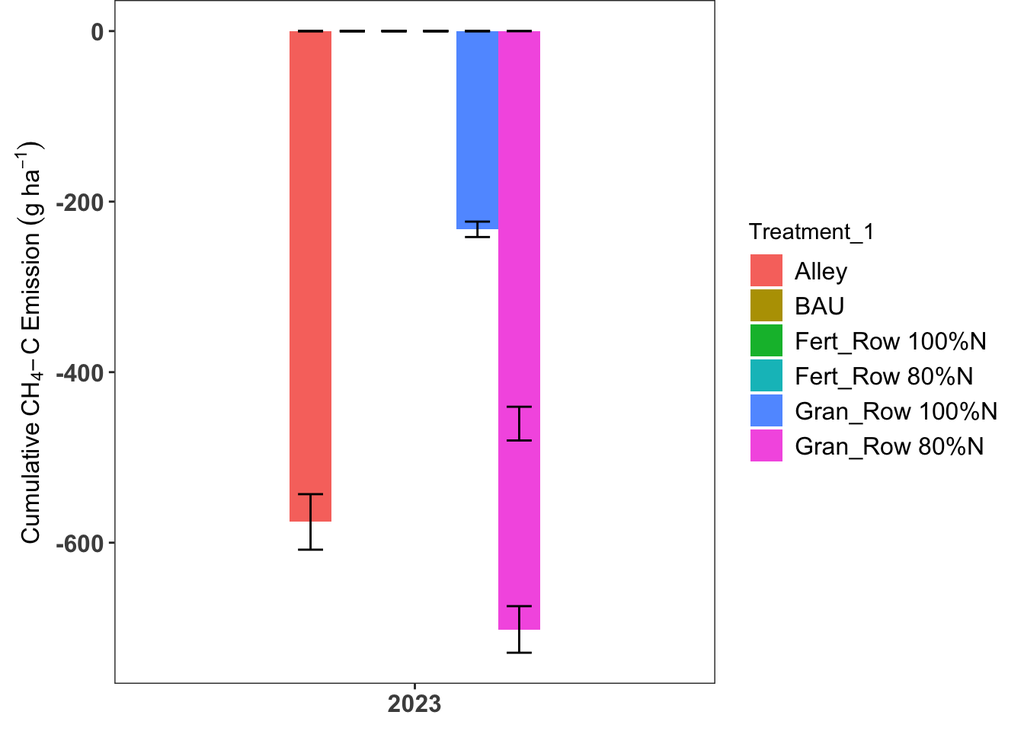

```r
#4A. Load the cumulative emissions dataset.
cumu_2020 <- readRDS("Cumulative GHGs emission_2023May-2023May_UBCF.rda")

#4B. Extract one year of data in order to create a graph depicting annual cumulative emissions.
annual <- cumu_2020[Datenew %like% "2024",c(2:5,8,11,14)] # Changed == to %like% to grab all of one year

#4C. Add a Year column and clean the data.
annual <- annual[,Year := as.factor(year(annual$Datenew)-1)][order(Year,Plot)]
 annual <- na.omit(annual, cols = c("cumu.kg.ha_co2c","cumu.g.ha_n2on")) # For removing any NA data before running ggplot

#4E. Summarize emissions by treatment and plot, resulting in three summary data frame for each greenhouse gas.  This also displays summary statistics including mean cumulative emission, standard error (SE), and sample size (N).
annual.co2 <- summarySE(annual, measurevar = "cumu.kg.ha_co2c", groupvars=c("Plot","Treatment_1", "Year"))
annual.n2o <- summarySE(annual, measurevar = "cumu.g.ha_n2on", groupvars=c("Plot","Treatment_1", "Year"))
annual.ch4 <- summarySE(annual, measurevar = "cumu.g.ha_ch4c", groupvars=c("Plot","Treatment_1", "Year"))

#4F. Create cumulative emissions bar graphs for each greenhouse gas by treatment and year.

# Methane:
# Again, to ensure plots display correctly, make sure to remove any NA values, replacing them with a 0.
annual.ch4[is.na(annual.ch4)] <- 0

p4 <- ggplot(annual.ch4,aes(x = Year, y = cumu.g.ha_ch4c,fill = Treatment_1))+
  geom_bar(stat = "identity",position = "dodge", width = 0.5)+
  geom_errorbar(aes(ymax=cumu.g.ha_ch4c+se, ymin=cumu.g.ha_ch4c-se),stat = "identity",
                position = position_dodge(width=0.5), width = 0.3)+
  ylab(expression(Cumulative~CH[4]*-C~Emission~(g~ha^-1)))+
  scale_y_continuous(n.breaks=6)+
  theme_bw()+
  theme(panel.grid.major = element_blank(),
        panel.grid.minor = element_blank(),
        plot.margin = unit(c(0,0.5,0.5,0.5), "lines"),
        legend.text = element_text(size = 12),
        axis.title.y = element_text(size= 12),
        axis.text=element_text(size=12,face = 'bold'),
        axis.title.x = element_blank())

p4
```

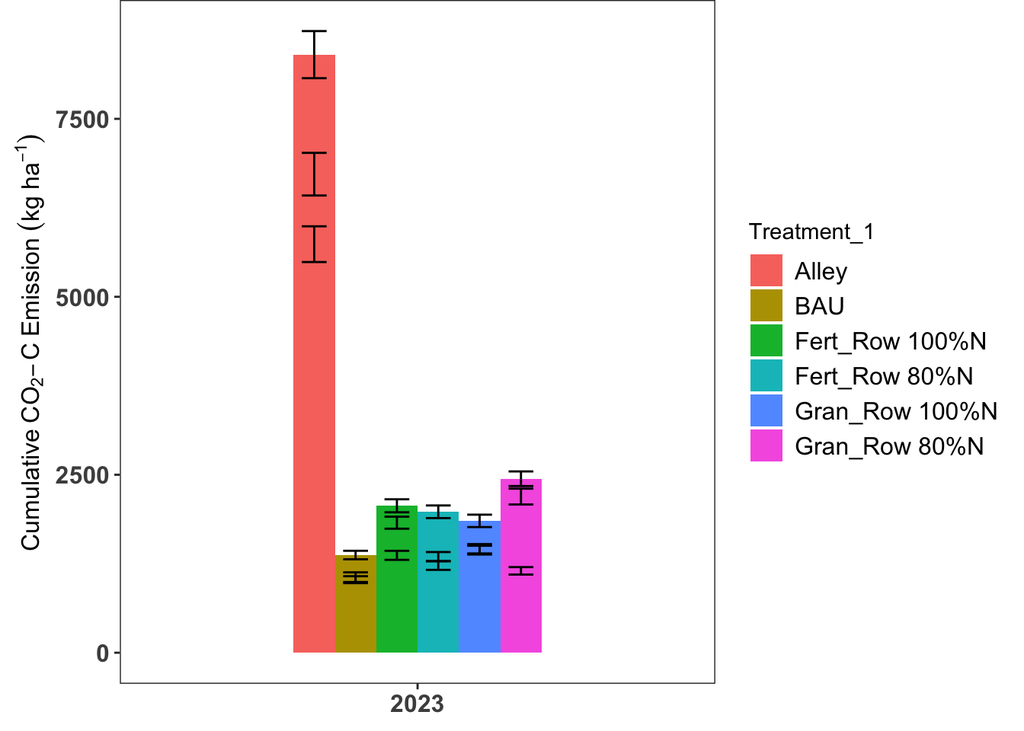

```r
# Carbon dioxide:
p5 <- ggplot(annual.co2,aes(x = Year, y = cumu.kg.ha_co2c,fill = Treatment_1))+
  geom_bar(stat = "identity",position = "dodge", width = 0.5)+
  geom_errorbar(aes(ymax=cumu.kg.ha_co2c+se, ymin=cumu.kg.ha_co2c-se),stat = "identity",
                position = position_dodge(width = 0.5), width = 0.3)+
  ylab(expression(Cumulative~CO[2]*-C~Emission~(kg~ha^-1)))+
  scale_y_continuous(n.breaks=5)+
  theme_bw()+
  theme(panel.grid.major = element_blank(),
        panel.grid.minor = element_blank(),
        plot.margin = unit(c(0,0.5,0.5,0.5), "lines"),
        legend.text = element_text(size = 12),
        axis.title.y = element_text(size= 12),
        axis.text=element_text(size=12,face = 'bold'),
        axis.title.x = element_blank())

p5
```

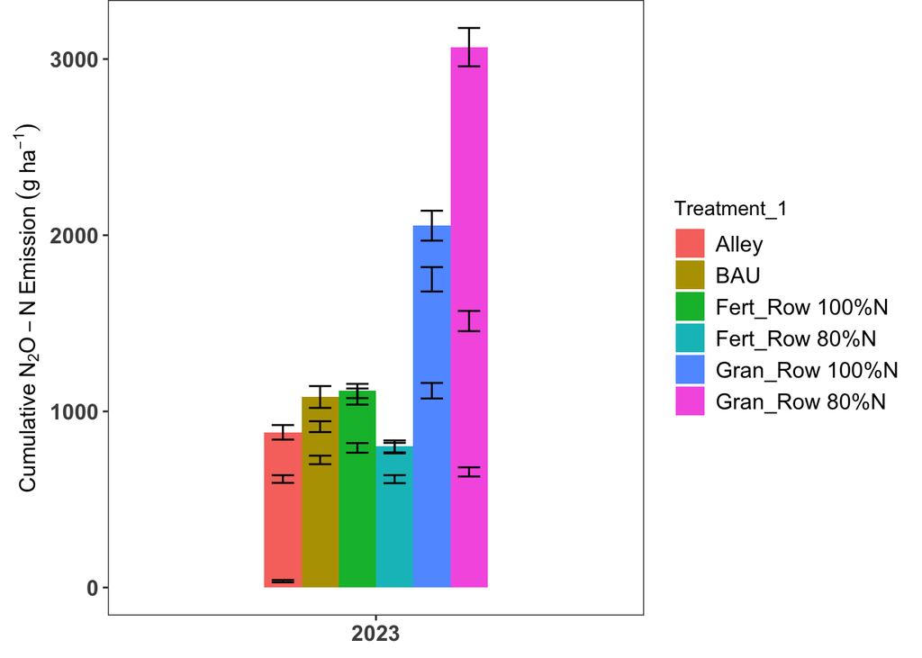

```r
# Nitrous oxide:
p6 <- ggplot(annual.n2o,aes(x = Year, y = cumu.g.ha_n2on,fill = Treatment_1))+
  geom_bar(stat = "identity",position = "dodge", width = 0.5)+
  geom_errorbar(aes(ymax=cumu.g.ha_n2on+se, ymin=cumu.g.ha_n2on-se),stat = "identity",
                position = position_dodge(width=0.5), width = 0.3)+
  ylab(expression(Cumulative~N[2]*O-N~Emission~(g~ha^-1)))+
  scale_y_continuous(n.breaks=5)+
  theme_bw()+
  theme(panel.grid.major = element_blank(),
        panel.grid.minor = element_blank(),
        plot.margin = unit(c(0,0.5,0.5,0.5), "lines"),
        legend.text = element_text(size = 12),
        axis.title.y = element_text(size= 12),
        axis.text=element_text(size=12,face = 'bold'),
        axis.title.x = element_blank())

p6
```

```r
#4G. To export plots into image files, use the code below:
ggexport(p6, width = 1000,height = 1000, res = 150,
         filename = "2M2L_AnnualN2O_2020.jpg")
```

```
## file saved to 2M2L_AnnualN2O_2020.jpg
```